# DI_Demo

Lucia Michielin

2024-02-26

## Introduction

This is a short demo to show how you can create a .gif that would record the sentiment evolution across Jane Austen books. To do so we need to follow these steps

1. Create a Table where we are going to automatically extract each word in Jane Austen books.
2. Calculate the sentiment values for subset of each chapters
3. Plot a graph for each book that will show the sentiment values
4. Collate the single graphs into a single gif

### 1. Create a word collection table

For each words we are going to collect information about

- the book it belongs to
- the line number where it could be found
- the chapter where it could be found
- the word itself

```r
AustenTable <- austen_books() %>% #create a new file named AustenTable that will extract info from austen_books
  group_by(book) %>% # group by every single book then
  mutate( # manipulate the data to create
    linenumber = row_number(), # a line number column that would count in which row the word was
    chapter = cumsum(str_detect(text, # the chapter number. We can do so by using regex and find lines starting with chapter followed by a space and a letter
                                regex("^chapter [\\divxlc]",
                                      ignore_case = TRUE)))) %>%
  ungroup() %>% #  This line removes the grouping, so subsequent operations will be applied to the entire dataset rather than grouped subsets.
  unnest_tokens(word, text) # This tokenises the text column, splitting it into individual words and creating a new row for each word

head(AustenTable)
```

```
## # A tibble: 6 × 4
##   book                linenumber chapter word
##   <fct>                    <int>   <int> <chr>
## 1 Sense & Sensibility          1       0 sense
## 2 Sense & Sensibility          1       0 and
## 3 Sense & Sensibility          1       0 sensibility
## 4 Sense & Sensibility          3       0 by
## 5 Sense & Sensibility          3       0 jane
## 6 Sense & Sensibility          3       0 austen
```

```r
jane_austen_sentiment <- AustenTable %>% # Load Jane Austen's books dataset and start a chain of operations to create a Jane_austen_sentiment dataset
  inner_join(get_sentiments("bing"), relationship = 'many-to-many') %>% # Join the dataset with the Bing lexicon sentiment dictionary
  group_by(book, chapter) %>%   # Group the dataset by book and chapter
  mutate(index = rep(1:10, each = ceiling(n() / 10), length.out = n())) %>% # Create an index to split the chapters into 10 segments no matter how long the chapter it is
  group_by(book, chapter, index) %>% # Regroup the dataset by book, chapter, and index
  count(sentiment) %>%  # Count the occurrences of each sentiment within each segment
  pivot_wider(names_from = sentiment, values_from = n, values_fill = 0) %>% # Reshape the data from long to wide format
  mutate(sentiment = positive - negative,index= as.factor(index))%>%  # Calculate sentiment score (positive - negative) for each segment
  filter(!chapter=="0") # Filter out chapters with the value "0" (if any)

head(jane_austen_sentiment)
```

```
## # A tibble: 6 × 6
## # Groups:   book, chapter, index [6]
##   book                chapter index negative positive sentiment
##   <fct>                 <int> <fct>    <int>    <int>     <int>
## 1 Sense & Sensibility       1 1            2       11         9
## 2 Sense & Sensibility       1 2            4        9         5
## 3 Sense & Sensibility       1 3            7        6        -1
## 4 Sense & Sensibility       1 4            3       10         7
## 5 Sense & Sensibility       1 5            4        9         5
## 6 Sense & Sensibility       1 6            3       10         7
```

### 3. Plot a graph for each book

Plot a graph for each book that will show the sentiment values tapestry across the book To do so we need to do a series of small steps

#### A. Create a directory to which the images will be written

```r
dir_out <- file.path("outputs/Austen") # Define the directory path where the outputs will be saved
dir.create(dir_out, recursive = TRUE) # Create the directory if it doesn't already exist
```

#### B. List all the books that are inside our dataset

```r
books <- unique(jane_austen_sentiment$book)
books
```

```
## [1] Sense & Sensibility Pride & Prejudice   Mansfield Park
## [4] Emma                Northanger Abbey    Persuasion
## 6 Levels: Sense & Sensibility Pride & Prejudice Mansfield Park ... Persuasion
```

```r
most_chapter <- max(jane_austen_sentiment$chapter, na.rm = TRUE)# Find the maximum chapter number in the dataset 'jane_austen_sentiment'
most_chapter
```

```
## [1] 61
```

#### D. Print a graph for each book using a for loop

Now we have all that we need to create a for loop that will automatically create a graph for each book. A “for” loop is a control flow statement in programming languages that allows you to repeatedly execute a block of code a specified number of times or iterate over a sequence of values.

```r
for (y in books) {# Iterate over each book in the 'books' vector y is the name we are going to the iteration variable it can be anything as long as you are consistent

  p <- # p is just a name we are giving to the plot again you can change it as long as you are consistent
    jane_austen_sentiment %>%
    filter(book == y) %>% # Filter the 'jane_austen_sentiment' dataset for the current book
    ggplot(aes(chapter,index, fill= sentiment)) +  # Create a ggplot object with chapter, index, and sentiment as aesthetics
    geom_tile() +# Add a tile layer to create a heatmap
    scale_x_continuous(breaks=seq(1,most_chapter,1), expand = c(0,0))+  # Customise x-axis scale to show breaks from 1 to 'most_chapter'
    scale_fill_gradient(low="blue", high="red", limits = c(-20, 40))+# Customise fill scale to use a gradient from blue to red
    theme_bw()+ # Apply a black-and-white theme
    guides(fill="none")+  # Remove the fill legend
    ggtitle(y)+ # Add a title to the plot with the current book's name
    coord_fixed(ratio = 1, ylim = c(10,1), xlim = c(0.5,most_chapter+0.5))+  # Fix the aspect ratio and set limits for y and x axes
    theme(  # Customize theme to remove y-axis labels and ticks
      axis.title.y = element_blank(),
      axis.text.y= element_blank(),
      axis.ticks.y = element_blank()
    )

  fp <- file.path(dir_out, paste0(y, ".png"))# Define the file path where the plot will be saved

  ggsave(plot = p,  # Save the ggplot object as a PNG file
         filename = fp,   # File path where the plot will be saved
         device = "png", # Output device type (PNG format)
         width=3500,# Width of the output in pixels
         height = 1000, # Height of the output in pixels
         units = "px") # Units of width and height (pixels)

}# Close the loop
```

The bit of code below it is just to look at one of the plots created

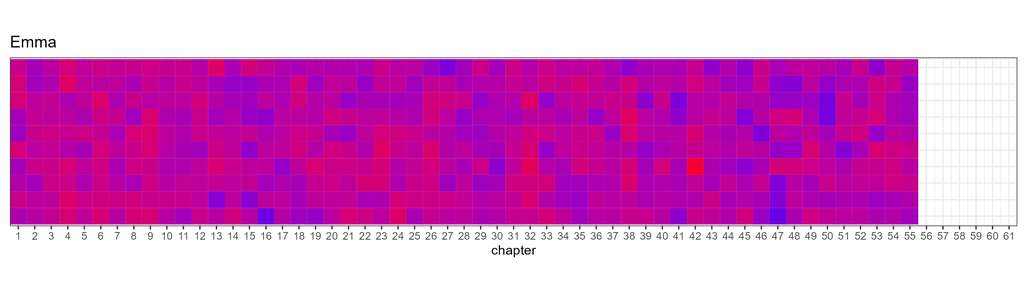

```r
Image <- image_read('outputs/Austen/Emma.png')
Image
```

Good! We are almost there now we need to create a gif out of the single plots

### 4. Create and Save a gif

#### A. List file names and read in

```r
imgs <- list.files(dir_out, full.names = TRUE) # List all file names in the directory 'dir_out' and store them in 'imgs'
img_list <- lapply(imgs, image_read)  # Read each image file from the list of file names using 'image_read' and store them in 'img_list'
```

#### B. Join the images together

```r
img_joined <- image_join(img_list) # Join the list of images into a single animated image using 'image_join'
```

#### C. Animate 1 frame per second

```r
img_animated <- image_animate(img_joined, fps = 1) # Create an animated image from the joined image with a frame rate of 1 frame per second using 'image_animate'
```

#### D. Save to disk

```r
image_write(image = img_animated,
            path = "outputs/austen.gif")
```

Let’s look at what we have done

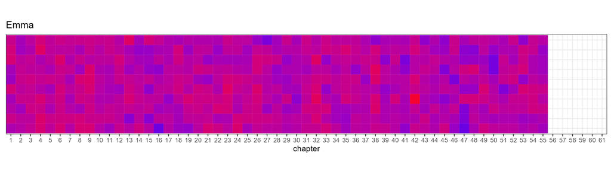

```r
img_animated
```

# The End

This is the end of this demo. Feel free to play around with it and modify it as you want